# Developing Data Products Course Project

3/9/2018

## Swiss Fertility and Socioeconomic Indicators (1888) Data

### Standardized fertility measure and socio-economic indicators for each of 47 French-speaking provinces of Switzerland at about 1888. Includes a data frame with 47 observations on 6 variables, each of which is in percent, i.e., in [0, 100].

```r
data(swiss)
str(swiss)
```

```
## 'data.frame':    47 obs. of  6 variables:
##  $ Fertility       : num  80.2 83.1 92.5 85.8 76.9 76.1 83.8 92.4 82.4 82.9 ...
##  $ Agriculture     : num  17 45.1 39.7 36.5 43.5 35.3 70.2 67.8 53.3 45.2 ...
##  $ Examination     : int  15 6 5 12 17 9 16 14 12 16 ...
##  $ Education       : int  12 9 5 7 15 7 7 8 7 13 ...
##  $ Catholic        : num  9.96 84.84 93.4 33.77 5.16 ...
##  $ Infant.Mortality: num  22.2 22.2 20.2 20.3 20.6 26.6 23.6 24.9 21 24.4 ...
```

## Summary Plot of Swiss data

### The first tab of the Shiny application allows the user to the choose x- and y-axes for a scatterplot, along with a regression line to more deeply explore the distributions and relationships in the data.

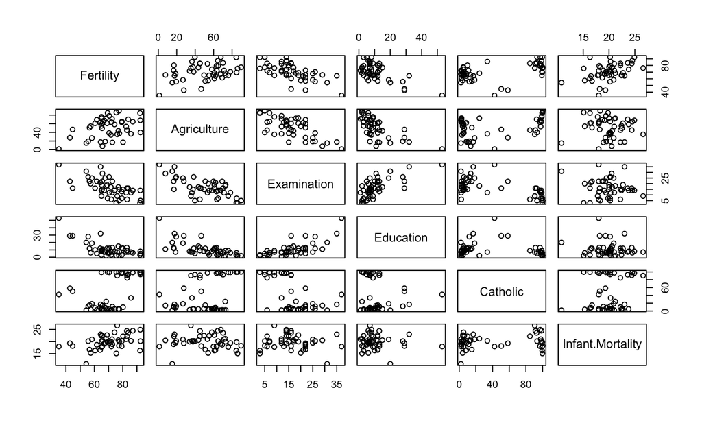

## Fitting a Model

### The second tab in the Shiny app allows the user to fit a machine learning model to predict the Fertility for provinces. The user can specify the **size of the test/holdout set**, which of the **features to use**, and can choose from **three different machine learning algorithms**: a generalized linear model (GLM), a k-nearest neighbors (KNN) regressor, or a random forest (RF) regressor.

### This gives the user many options for machine learning on the dataset by using simple widgets and hiding the rest of the coding details from them.

## Example of Fit results

### This is an example of the fit result plot using a GLM with all the features and a test set size of 30%. We plot the actual fertility values on the x-axis and the fitted values on the y-axis. We also include the mean squared error (MSE) in red text on the plot.

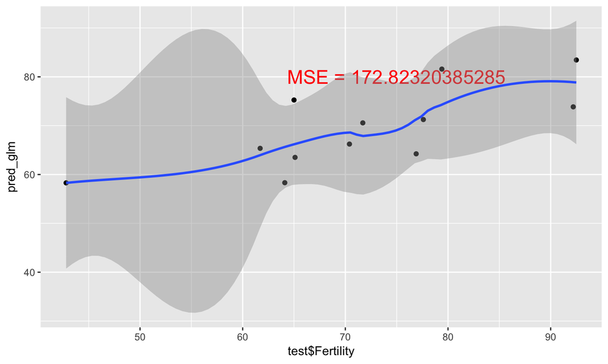